# 🏠 King County Housing — Exploratory Data Analysis

**Datasets**

**Goals**

1. Understand the distribution and shape of the target variable (`price`)
2. Identify the strongest predictors of price
3. Detect outliers, data-quality issues, and skewed features
4. Explore geographic and temporal patterns
5. Assess demographic enrichment signal
6. Confirm that the future/unseen set is drawn from the same distribution

## 0 · Setup & Data Loading

```python
import warnings
warnings.filterwarnings("ignore")

import numpy as np
import pandas as pd
import matplotlib.pyplot as plt
import matplotlib.ticker as mticker
import seaborn as sns
from scipy import stats

# ── plotting defaults ────────────────────────────────────────────────────
sns.set_theme(style="whitegrid", palette="muted", font_scale=1.05)
plt.rcParams.update({"figure.dpi": 110, "figure.figsize": (12, 5)})
PRICE_COLOR  = "#2e86de"
ACCENT_COLOR = "#ee5a24"
GREEN        = "#10ac84"

# ── load ─────────────────────────────────────────────────────────────────
DATA_DIR = "./data"

train   = pd.read_csv(f"{DATA_DIR}/kc_house_data.csv")
future  = pd.read_csv(f"{DATA_DIR}/future_unseen_examples.csv")
zipdemo = pd.read_csv(f"{DATA_DIR}/zipcode_demographics.csv")

# parse date
train["date"] = pd.to_datetime(train["date"], format="%Y%m%dT%H%M%S", errors="coerce")
train["sale_year"]  = train["date"].dt.year
train["sale_month"] = train["date"].dt.month
train["sale_ym"]    = train["date"].dt.to_period("M")

print(f"train   : {train.shape}")
print(f"future  : {future.shape}")
print(f"zipdemo : {zipdemo.shape}")
train.head(3)
```

```
train   : (21613, 24)
future  : (100, 18)
zipdemo : (70, 27)
```

|  | id | date | price | bedrooms | bathrooms | sqft_living | sqft_lot | floors | waterfront | view | ... | yr_built | yr_renovated | zipcode | lat | long | sqft_living15 | sqft_lot15 | sale_year | sale_month | sale_ym |
| --- | --- | --- | --- | --- | --- | --- | --- | --- | --- | --- | --- | --- | --- | --- | --- | --- | --- | --- | --- | --- | --- |
| 0 | 7129300520 | 2014-10-13 | 221900.0 | 3 | 1.00 | 1180 | 5650 | 1.0 | 0 | 0 | ... | 1955 | 0 | 98178 | 47.5112 | -122.257 | 1340 | 5650 | 2014 | 10 | 2014-10 |
| 1 | 6414100192 | 2014-12-09 | 538000.0 | 3 | 2.25 | 2570 | 7242 | 2.0 | 0 | 0 | ... | 1951 | 1991 | 98125 | 47.7210 | -122.319 | 1690 | 7639 | 2014 | 12 | 2014-12 |
| 2 | 5631500400 | 2015-02-25 | 180000.0 | 2 | 1.00 | 770 | 10000 | 1.0 | 0 | 0 | ... | 1933 | 0 | 98028 | 47.7379 | -122.233 | 2720 | 8062 | 2015 | 2 | 2015-02 |

3 rows × 24 columns

## 1 · Dataset Overview

```python
# ── schema & dtypes ────────────────────────────────────────────────────
print("=== Training columns ===")
print(train.dtypes.to_string())
print()
print("=== Future columns ===")
print(future.dtypes.to_string())
print()
print("=== Zip-demographic columns ===")
print(zipdemo.dtypes.to_string())
```

```
=== Training columns ===
id                        int64
date             datetime64[us]
price                   float64
bedrooms                  int64
bathrooms               float64
sqft_living               int64
sqft_lot                  int64
floors                  float64
waterfront                int64
view                      int64
condition                 int64
grade                     int64
sqft_above                int64
sqft_basement             int64
yr_built                  int64
yr_renovated              int64
zipcode                   int64
lat                     float64
long                    float64
sqft_living15             int64
sqft_lot15                int64
sale_year                 int32
sale_month                int32
sale_ym               period[M]

=== Future columns ===
bedrooms           int64
bathrooms        float64
sqft_living        int64
sqft_lot           int64
floors           float64
waterfront         int64
view               int64
condition          int64
grade              int64
sqft_above         int64
sqft_basement      int64
yr_built           int64
yr_renovated       int64
```

[output cut: 19 more lines]

```
edctn_assoc_dgre_qty      float64
edctn_bchlr_dgre_qty      float64
edctn_prfsnl_qty          float64
per_urbn                  float64
per_sbrbn                 float64
per_farm                  float64
per_non_farm              float64
per_less_than_9           float64
per_9_to_12               float64
per_hsd                   float64
per_some_clg              float64
per_assoc                 float64
per_bchlr                 float64
per_prfsnl                float64
zipcode                     int64
```

```python
# ── null audit ──────────────────────────────────────────────────────────
def null_report(df, name):
    n = df.isnull().sum()
    pct = n / len(df) * 100
    report = pd.DataFrame({"nulls": n, "pct": pct.round(2)})
    report = report[report.nulls > 0]
    if report.empty:
        print(f"{name}: ✓ No missing values")
    else:
        print(f"\n{name} — missing values:")
        print(report)

null_report(train,   "train")
null_report(future,  "future")
null_report(zipdemo, "zipdemo")
```

```
train: ✓ No missing values
future: ✓ No missing values
zipdemo: ✓ No missing values
```

```python
# ── basic descriptive stats ──────────────────────────────────────────────
# train.describe().T.style \
#     .background_gradient(cmap="Blues", subset=["mean","std","50%"]) \
#     .format("{:.2f}")
```

## 2 · Target Variable — `price`

> Home prices are **right-skewed**: a handful of luxury properties pull the mean well above the median. A log transform normalises the distribution, which is why models should be trained on `log1p(price)`.

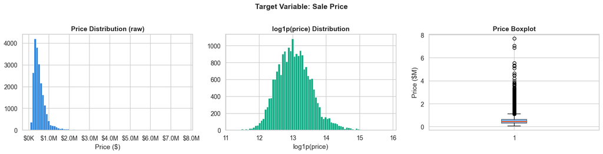

```
Skewness: 4.024   Kurtosis: 34.586
Mean  : $     540,088
Median: $     450,000
Std   : $     367,127
Min   : $      75,000
Max   : $   7,700,000
```

```python
fig, axes = plt.subplots(1, 3, figsize=(16, 4))

# Raw price
axes[0].hist(train["price"], bins=80, color=PRICE_COLOR, edgecolor="white", linewidth=0.4)
axes[0].set_title("Price Distribution (raw)", fontweight="bold")
axes[0].set_xlabel("Price ($)")
axes[0].xaxis.set_major_formatter(mticker.FuncFormatter(lambda x, _: f"${x/1e6:.1f}M" if x >= 1e6 else f"${x/1e3:.0f}K"))

# Log-transformed
log_price = np.log1p(train["price"])
axes[1].hist(log_price, bins=80, color=GREEN, edgecolor="white", linewidth=0.4)
axes[1].set_title("log1p(price) Distribution", fontweight="bold")
axes[1].set_xlabel("log1p(price)")

# Box plot
axes[2].boxplot(train["price"] / 1e6, vert=True, patch_artist=True,
                boxprops=dict(facecolor=PRICE_COLOR, alpha=0.6),
                medianprops=dict(color=ACCENT_COLOR, linewidth=2))
axes[2].set_title("Price Boxplot", fontweight="bold")
axes[2].set_ylabel("Price ($M)")

plt.suptitle("Target Variable: Sale Price", fontsize=14, fontweight="bold", y=1.01)
plt.tight_layout()
plt.show()

skew = train["price"].skew()
kurt = train["price"].kurtosis()
print(f"Skewness: {skew:.3f}   Kurtosis: {kurt:.3f}")
print(f"Mean  : ${train['price'].mean():>12,.0f}")
print(f"Median: ${train['price'].median():>12,.0f}")
print(f"Std   : ${train['price'].std():>12,.0f}")
print(f"Min   : ${train['price'].min():>12,.0f}")
print(f"Max   : ${train['price'].max():>12,.0f}")
```

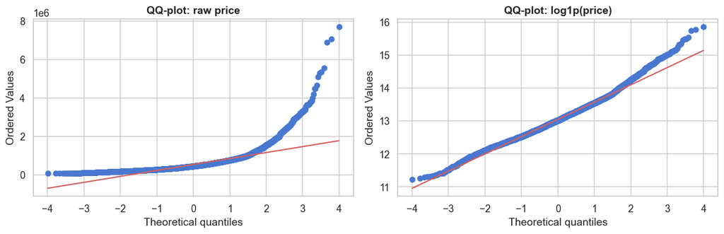

```python
# ── QQ-plot: does log price follow a normal distribution? ────────────────
fig, axes = plt.subplots(1, 2, figsize=(12, 4))
stats.probplot(train["price"],      dist="norm", plot=axes[0])
axes[0].set_title("QQ-plot: raw price",       fontweight="bold")
stats.probplot(np.log1p(train["price"]), dist="norm", plot=axes[1])
axes[1].set_title("QQ-plot: log1p(price)",    fontweight="bold")
plt.tight_layout(); plt.show()
```

## 3 · Numerical Feature Distributions

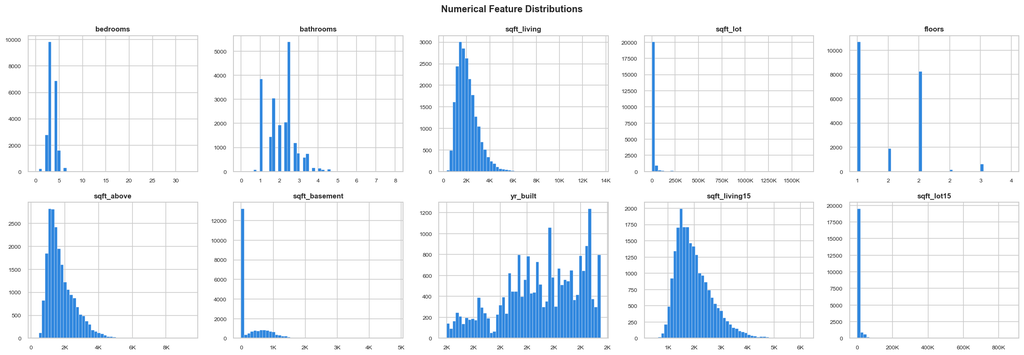

```python
num_cols = ["bedrooms", "bathrooms", "sqft_living", "sqft_lot",
            "floors", "sqft_above", "sqft_basement",
            "yr_built", "sqft_living15", "sqft_lot15"]

fig, axes = plt.subplots(2, 5, figsize=(20, 7))
axes = axes.flatten()

for ax, col in zip(axes, num_cols):
    ax.hist(train[col], bins=50, color=PRICE_COLOR, edgecolor="white", linewidth=0.3)
    ax.set_title(col, fontweight="bold", fontsize=10)
    ax.tick_params(labelsize=8)
    ax.xaxis.set_major_formatter(mticker.FuncFormatter(
        lambda x, _: f"{x/1e3:.0f}K" if abs(x) >= 1000 else f"{x:.0f}"))

plt.suptitle("Numerical Feature Distributions", fontsize=13, fontweight="bold")
plt.tight_layout(); plt.show()
```

```python
# ── skewness table ───────────────────────────────────────────────────────
skew_df = train[num_cols].skew().sort_values(ascending=False).reset_index()
skew_df.columns = ["feature", "skewness"]
skew_df["flag"] = skew_df["skewness"].apply(
    lambda s: "⚠ high" if abs(s) > 1 else ("~ moderate" if abs(s) > 0.5 else "✓ ok"))
print(skew_df.to_string(index=False))
```

```
      feature  skewness       flag
     sqft_lot 13.060019     ⚠ high
   sqft_lot15  9.506743     ⚠ high
     bedrooms  1.974300     ⚠ high
sqft_basement  1.577965     ⚠ high
  sqft_living  1.471555     ⚠ high
   sqft_above  1.446664     ⚠ high
sqft_living15  1.108181     ⚠ high
       floors  0.616177 ~ moderate
    bathrooms  0.511108 ~ moderate
     yr_built -0.469805       ✓ ok
```

## 4 · Categorical & Ordinal Features

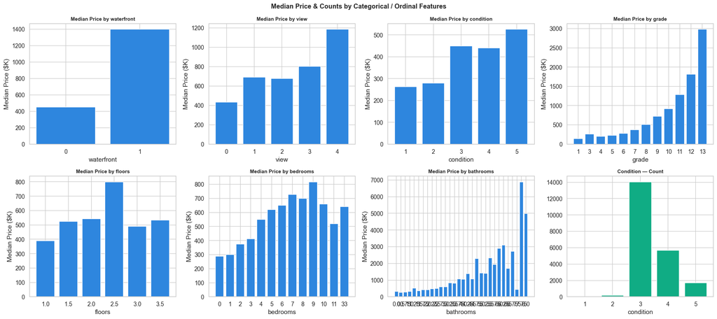

```python
cat_cols = ["waterfront", "view", "condition", "grade", "floors",
            "bedrooms", "bathrooms"]

fig, axes = plt.subplots(2, 4, figsize=(20, 9))
axes = axes.flatten()

for ax, col in zip(axes, cat_cols):
    order = sorted(train[col].unique())
    medians = train.groupby(col)["price"].median().reindex(order)
    bars = ax.bar(medians.index.astype(str), medians.values / 1e3,
                  color=PRICE_COLOR, edgecolor="white")
    ax.set_title(f"Median Price by {col}", fontweight="bold", fontsize=10)
    ax.set_xlabel(col); ax.set_ylabel("Median Price ($K)")

# count distribution in last panel
axes[7].bar(train["condition"].value_counts().sort_index().index.astype(str),
            train["condition"].value_counts().sort_index().values,
            color=GREEN, edgecolor="white")
axes[7].set_title("Condition — Count", fontweight="bold", fontsize=10)
axes[7].set_xlabel("condition")

plt.suptitle("Median Price & Counts by Categorical / Ordinal Features",
             fontsize=13, fontweight="bold")
plt.tight_layout(); plt.show()
```

```python
# ── waterfront premium ───────────────────────────────────────────────────
wf = train.groupby("waterfront")["price"].agg(["median","mean","count"])
wf.index = ["No Waterfront", "Waterfront"]
wf.columns = ["Median Price", "Mean Price", "Count"]
wf["Median Price"] = wf["Median Price"].apply(lambda x: f"${x:,.0f}")
wf["Mean Price"]   = wf["Mean Price"].apply(lambda x: f"${x:,.0f}")
print("Waterfront Premium:")
print(wf.to_string())
```

```
Waterfront Premium:
              Median Price  Mean Price  Count
No Waterfront     $450,000    $531,564  21450
Waterfront      $1,400,000  $1,661,876    163
```

## 5 · Correlation Analysis

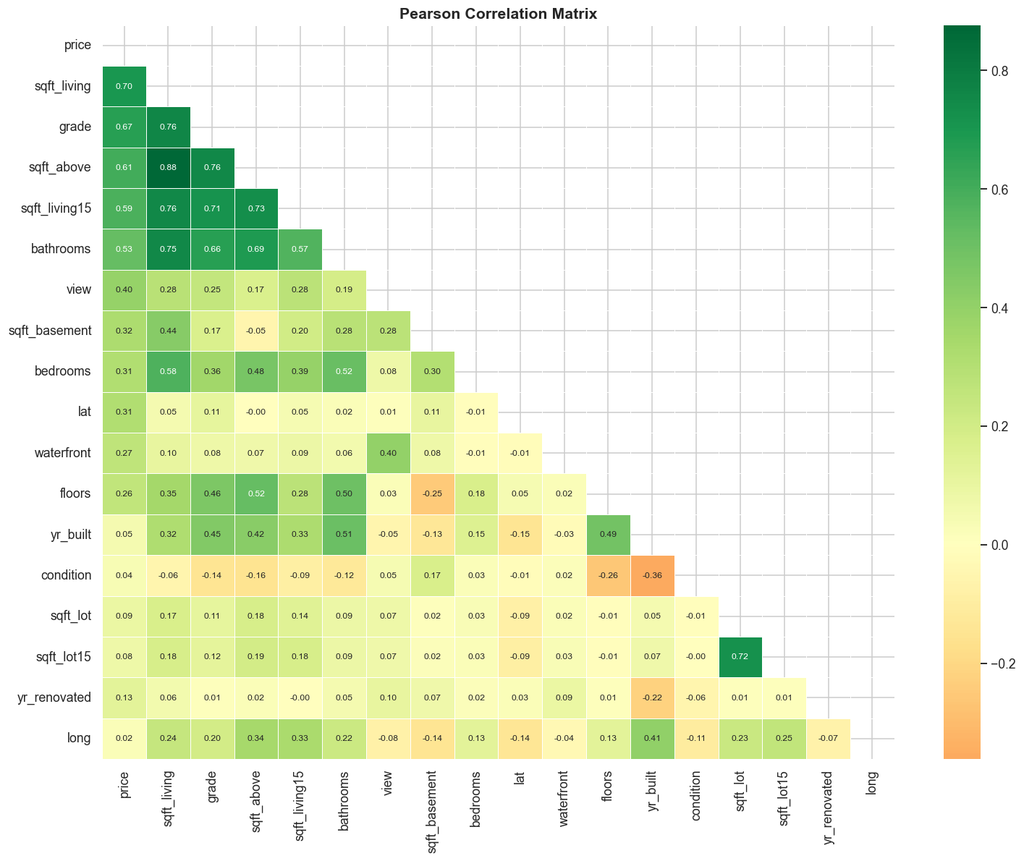

```python
corr_cols = ["price","sqft_living","grade","sqft_above","sqft_living15",
             "bathrooms","view","sqft_basement","bedrooms","lat",
             "waterfront","floors","yr_built","condition","sqft_lot",
             "sqft_lot15","yr_renovated","long"]

corr = train[corr_cols].corr()

fig, ax = plt.subplots(figsize=(14, 11))
mask = np.triu(np.ones_like(corr, dtype=bool))
sns.heatmap(corr, mask=mask, annot=True, fmt=".2f", cmap="RdYlGn",
            center=0, linewidths=0.4, ax=ax, annot_kws={"size": 8})
ax.set_title("Pearson Correlation Matrix", fontsize=14, fontweight="bold")
plt.tight_layout(); plt.show()
```

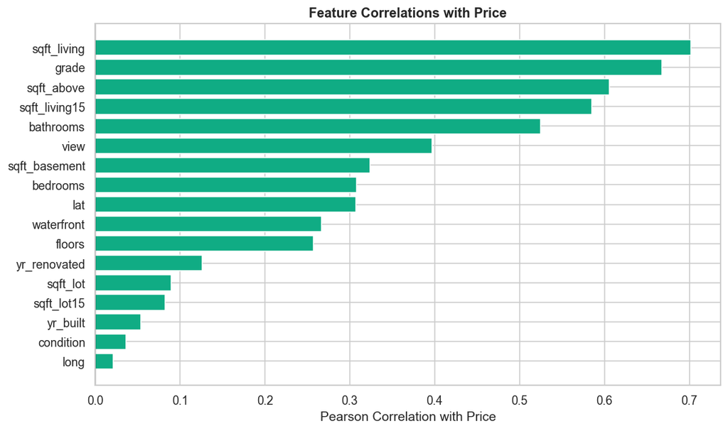

```
Top 5 positive:
sqft_living      0.702035
grade            0.667434
sqft_above       0.605567
sqft_living15    0.585379
bathrooms        0.525138

Top 5 negative:
sqft_lot      0.089661
sqft_lot15    0.082447
yr_built      0.054012
condition     0.036362
long          0.021626
```

```python
# ── top correlations with price ──────────────────────────────────────────
price_corr = train[corr_cols].corr()["price"].drop("price").sort_values(key=abs, ascending=False)
fig, ax = plt.subplots(figsize=(10, 6))
colors = [GREEN if v > 0 else ACCENT_COLOR for v in price_corr.values]
bars = ax.barh(price_corr.index[::-1], price_corr.values[::-1], color=colors[::-1], edgecolor="white")
ax.axvline(0, color="black", linewidth=0.8)
ax.set_xlabel("Pearson Correlation with Price")
ax.set_title("Feature Correlations with Price", fontsize=13, fontweight="bold")
plt.tight_layout(); plt.show()

print("Top 5 positive:")
print(price_corr.head(5).to_string())
print("\nTop 5 negative:")
print(price_corr.tail(5).to_string())
```

## 6 · Key Feature vs Price Scatter Plots

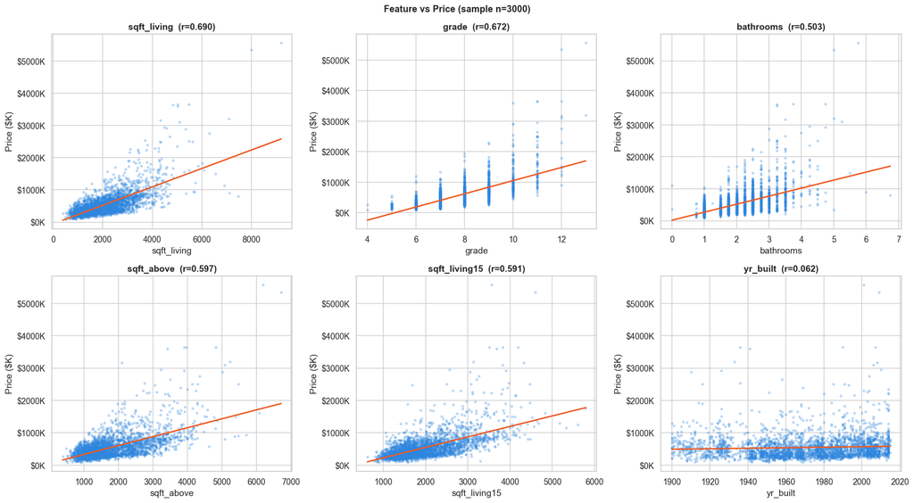

```python
scatter_cols = ["sqft_living", "grade", "bathrooms", "sqft_above",
                "sqft_living15", "yr_built"]

fig, axes = plt.subplots(2, 3, figsize=(18, 10))
axes = axes.flatten()

for ax, col in zip(axes, scatter_cols):
    sample = train.sample(n=min(3000, len(train)), random_state=42)
    ax.scatter(sample[col], sample["price"] / 1e3,
               alpha=0.25, s=8, color=PRICE_COLOR, rasterized=True)
    # trend line
    m, b = np.polyfit(sample[col], sample["price"] / 1e3, 1)
    xline = np.linspace(sample[col].min(), sample[col].max(), 100)
    ax.plot(xline, m * xline + b, color=ACCENT_COLOR, linewidth=2)
    r = sample[[col,"price"]].corr().iloc[0,1]
    ax.set_title(f"{col}  (r={r:.3f})", fontweight="bold")
    ax.set_xlabel(col); ax.set_ylabel("Price ($K)")
    ax.yaxis.set_major_formatter(mticker.FuncFormatter(lambda x, _: f"${x:.0f}K"))

plt.suptitle("Feature vs Price (sample n=3000)", fontsize=13, fontweight="bold")
plt.tight_layout(); plt.show()
```

## 7 · Geographic Analysis

> Latitude and longitude encode strong price signals — northern zip codes closer to Seattle tend to command higher prices.

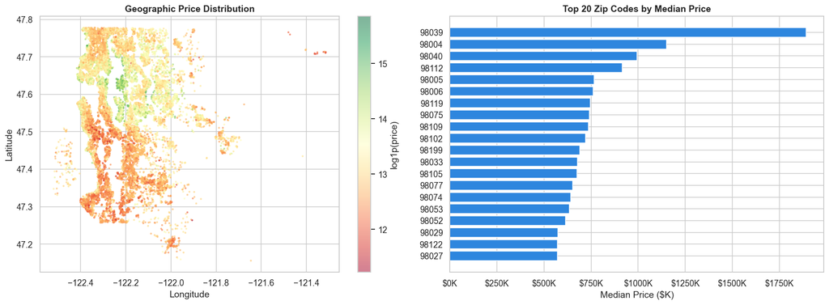

```python
fig, axes = plt.subplots(1, 2, figsize=(16, 6))

# Scatter: lat/long coloured by price
sc = axes[0].scatter(
    train["long"], train["lat"],
    c=np.log1p(train["price"]),
    cmap="RdYlGn", s=3, alpha=0.5, rasterized=True
)
plt.colorbar(sc, ax=axes[0], label="log1p(price)")
axes[0].set_title("Geographic Price Distribution", fontweight="bold")
axes[0].set_xlabel("Longitude"); axes[0].set_ylabel("Latitude")

# Median price by zipcode (top 20 most expensive)
zip_price = train.groupby("zipcode")["price"].median().sort_values(ascending=False).head(20)
axes[1].barh(zip_price.index.astype(str)[::-1], zip_price.values[::-1] / 1e3,
             color=PRICE_COLOR, edgecolor="white")
axes[1].set_title("Top 20 Zip Codes by Median Price", fontweight="bold")
axes[1].set_xlabel("Median Price ($K)")
axes[1].xaxis.set_major_formatter(mticker.FuncFormatter(lambda x, _: f"${x:.0f}K"))

plt.tight_layout(); plt.show()
```

```python
# ── lat/long individual correlations ─────────────────────────────────────
print(f"Correlation lat  vs price: {train[['lat','price']].corr().iloc[0,1]:.4f}")
print(f"Correlation long vs price: {train[['long','price']].corr().iloc[0,1]:.4f}")
```

```
Correlation lat  vs price: 0.3070
Correlation long vs price: 0.0216
```

## 8 · Temporal Patterns

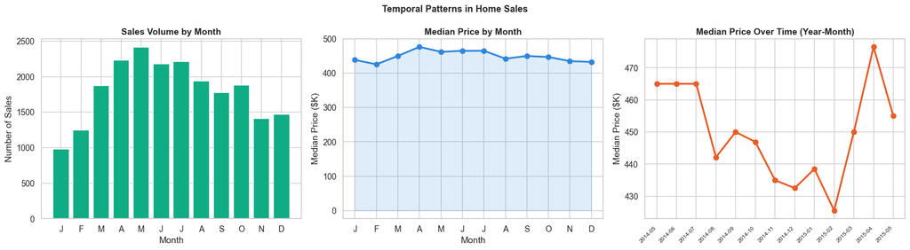

```python
fig, axes = plt.subplots(1, 3, figsize=(18, 5))

# Sales volume by month
monthly_count = train.groupby("sale_month").size()
axes[0].bar(monthly_count.index, monthly_count.values, color=GREEN, edgecolor="white")
axes[0].set_title("Sales Volume by Month", fontweight="bold")
axes[0].set_xlabel("Month"); axes[0].set_ylabel("Number of Sales")
axes[0].set_xticks(range(1,13))
axes[0].set_xticklabels(["J","F","M","A","M","J","J","A","S","O","N","D"])

# Median price by month
monthly_price = train.groupby("sale_month")["price"].median()
axes[1].plot(monthly_price.index, monthly_price.values / 1e3,
             marker="o", color=PRICE_COLOR, linewidth=2.5, markersize=7)
axes[1].fill_between(monthly_price.index, monthly_price.values / 1e3,
                     alpha=0.15, color=PRICE_COLOR)
axes[1].set_title("Median Price by Month", fontweight="bold")
axes[1].set_xlabel("Month"); axes[1].set_ylabel("Median Price ($K)")
axes[1].set_xticks(range(1,13))
axes[1].set_xticklabels(["J","F","M","A","M","J","J","A","S","O","N","D"])

# Monthly rolling median over the full period
ym_price = train.groupby("sale_ym")["price"].median().reset_index()
ym_price["sale_ym_str"] = ym_price["sale_ym"].astype(str)
axes[2].plot(range(len(ym_price)), ym_price["price"] / 1e3,
             marker="o", color=ACCENT_COLOR, linewidth=2.5, markersize=7)
axes[2].set_xticks(range(len(ym_price)))
axes[2].set_xticklabels(ym_price["sale_ym_str"], rotation=45, ha="right", fontsize=8)
axes[2].set_title("Median Price Over Time (Year-Month)", fontweight="bold")
axes[2].set_ylabel("Median Price ($K)")

plt.suptitle("Temporal Patterns in Home Sales", fontsize=13, fontweight="bold")
plt.tight_layout(); plt.show()
```

## 9 · Outlier Analysis

```python
# ── bedroom anomaly ───────────────────────────────────────────────────────
print("Bedroom value counts:")
print(train["bedrooms"].value_counts().sort_index().to_string())
print()
print("Extreme bedroom cases (>= 10):")
print(train[train["bedrooms"] >= 10][["id","price","bedrooms","bathrooms","sqft_living","grade"]].to_string(index=False))
```

```
Bedroom value counts:
bedrooms
0       13
1      199
2     2760
3     9824
4     6882
5     1601
6      272
7       38
8       13
9        6
10       3
11       1
33       1

Extreme bedroom cases (>= 10):
        id     price  bedrooms  bathrooms  sqft_living  grade
1773100755  520000.0        11       3.00         3000      7
 627300145 1148000.0        10       5.25         4590      9
5566100170  650000.0        10       2.00         3610      7
2402100895  640000.0        33       1.75         1620      7
8812401450  660000.0        10       3.00         2920      7
```

```python
# ── price outliers: IQR method ───────────────────────────────────────────
Q1 = train["price"].quantile(0.25)
Q3 = train["price"].quantile(0.75)
IQR = Q3 - Q1
upper_fence = Q3 + 3 * IQR

outliers = train[train["price"] > upper_fence]
print(f"IQR upper fence (3×IQR): ${upper_fence:,.0f}")
print(f"Outliers above fence: {len(outliers):,} ({len(outliers)/len(train)*100:.2f}%)")
print()
print("Price outlier summary:")
print(outliers["price"].describe().apply(lambda x: f"${x:,.0f}"))
```

```
IQR upper fence (3×IQR): $1,614,150
Outliers above fence: 420 (1.94%)

Price outlier summary:
count          $420
mean     $2,254,861
std        $764,588
min      $1,615,000
25%      $1,761,500
50%      $1,988,250
75%      $2,476,000
max      $7,700,000
Name: price, dtype: str
```

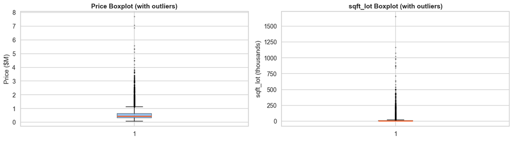

```python
# ── sqft_lot outliers ─────────────────────────────────────────────────────
fig, axes = plt.subplots(1, 2, figsize=(14, 4))

axes[0].boxplot(train["price"] / 1e6, vert=True, patch_artist=True,
                boxprops=dict(facecolor=PRICE_COLOR, alpha=0.5),
                medianprops=dict(color=ACCENT_COLOR, linewidth=2),
                flierprops=dict(marker=".", markersize=3, alpha=0.4))
axes[0].set_title("Price Boxplot (with outliers)", fontweight="bold")
axes[0].set_ylabel("Price ($M)")

axes[1].boxplot(train["sqft_lot"] / 1e3, vert=True, patch_artist=True,
                boxprops=dict(facecolor=GREEN, alpha=0.5),
                medianprops=dict(color=ACCENT_COLOR, linewidth=2),
                flierprops=dict(marker=".", markersize=3, alpha=0.4))
axes[1].set_title("sqft_lot Boxplot (with outliers)", fontweight="bold")
axes[1].set_ylabel("sqft_lot (thousands)")

plt.tight_layout(); plt.show()
```

## 10 · House Age & Renovation Impact

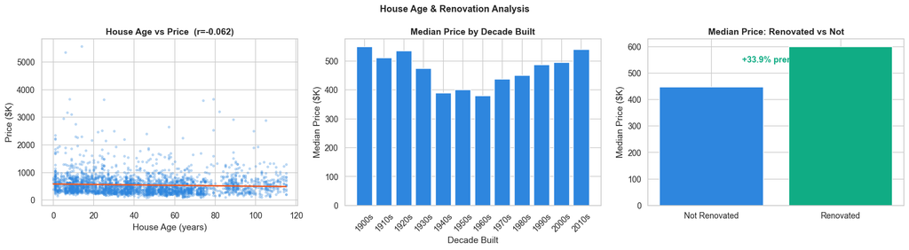

```
Renovated homes:     914 (4.2%)
Median price (not renovated): $448,000
Median price (renovated):     $600,000
Renovation premium:           +33.9%
```

```python
train["house_age"]    = 2015 - train["yr_built"]
train["was_renovated"] = (train["yr_renovated"] > 0).astype(int)

fig, axes = plt.subplots(1, 3, figsize=(18, 5))

# Age vs price scatter
sample = train.sample(3000, random_state=42)
axes[0].scatter(sample["house_age"], sample["price"] / 1e3,
                alpha=0.25, s=8, color=PRICE_COLOR, rasterized=True)
m, b = np.polyfit(sample["house_age"], sample["price"] / 1e3, 1)
xline = np.linspace(sample["house_age"].min(), sample["house_age"].max(), 100)
axes[0].plot(xline, m*xline+b, color=ACCENT_COLOR, linewidth=2)
r = sample[["house_age","price"]].corr().iloc[0,1]
axes[0].set_title(f"House Age vs Price  (r={r:.3f})", fontweight="bold")
axes[0].set_xlabel("House Age (years)"); axes[0].set_ylabel("Price ($K)")

# Price distribution by decade built
train["decade_built"] = (train["yr_built"] // 10 * 10).astype(str) + "s"
decade_order = sorted(train["decade_built"].unique())
decade_medians = train.groupby("decade_built")["price"].median().reindex(decade_order)
axes[1].bar(decade_medians.index, decade_medians.values / 1e3,
            color=PRICE_COLOR, edgecolor="white")
axes[1].set_title("Median Price by Decade Built", fontweight="bold")
axes[1].set_xlabel("Decade Built"); axes[1].set_ylabel("Median Price ($K)")
axes[1].tick_params(axis="x", rotation=45)

# Renovated vs not
reno_stats = train.groupby("was_renovated")["price"].median()
axes[2].bar(["Not Renovated", "Renovated"], reno_stats.values / 1e3,
            color=[PRICE_COLOR, GREEN], edgecolor="white")
axes[2].set_title("Median Price: Renovated vs Not", fontweight="bold")
axes[2].set_ylabel("Median Price ($K)")
pct_diff = (reno_stats[1] - reno_stats[0]) / reno_stats[0] * 100
axes[2].text(0.5, max(reno_stats.values)/1e3 * 0.9,
             f"+{pct_diff:.1f}% premium", ha="center", fontsize=12,
             color=GREEN, fontweight="bold")

plt.suptitle("House Age & Renovation Analysis", fontsize=13, fontweight="bold")
plt.tight_layout(); plt.show()

print(f"Renovated homes:     {train['was_renovated'].sum():,} ({train['was_renovated'].mean()*100:.1f}%)")
print(f"Median price (not renovated): ${reno_stats[0]:,.0f}")
print(f"Median price (renovated):     ${reno_stats[1]:,.0f}")
print(f"Renovation premium:           +{pct_diff:.1f}%")
```

## 11 · Zip-Code Demographic Enrichment

```python
# merge demographics into train
train_demo = train.merge(zipdemo, on="zipcode", how="left")
print(f"After merge: {train_demo.shape}")
print(f"Zip codes in train:   {train['zipcode'].nunique()}")
print(f"Zip codes in zipdemo: {zipdemo['zipcode'].nunique()}")
print(f"Coverage: {train['zipcode'].isin(zipdemo['zipcode']).mean()*100:.1f}%")
```

```
After merge: (21613, 53)
Zip codes in train:   70
Zip codes in zipdemo: 70
Coverage: 100.0%
```

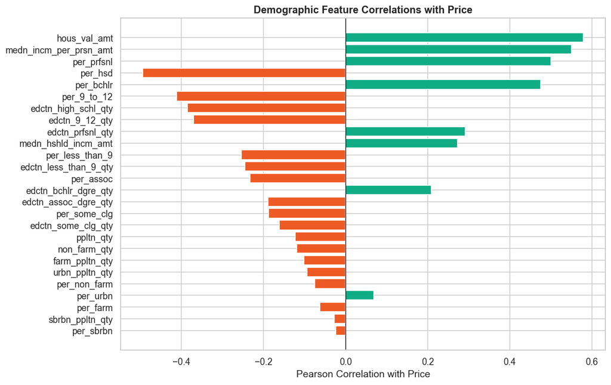

```
Top 6 demographic correlations with price:
hous_val_amt              0.579733
medn_incm_per_prsn_amt    0.549911
per_prfsnl                0.500262
per_hsd                  -0.494371
per_bchlr                 0.474896
per_9_to_12              -0.412200
```

```python
# ── demographic correlations with price ────────────────────────────────
demo_cols = [c for c in zipdemo.columns if c != "zipcode"]
demo_corr  = train_demo[demo_cols + ["price"]].corr()["price"].drop("price")
demo_corr  = demo_corr.sort_values(key=abs, ascending=False)

fig, ax = plt.subplots(figsize=(11, 7))
colors = [GREEN if v > 0 else ACCENT_COLOR for v in demo_corr.values]
ax.barh(demo_corr.index[::-1], demo_corr.values[::-1],
        color=colors[::-1], edgecolor="white")
ax.axvline(0, color="black", linewidth=0.8)
ax.set_xlabel("Pearson Correlation with Price")
ax.set_title("Demographic Feature Correlations with Price", fontsize=13, fontweight="bold")
plt.tight_layout(); plt.show()

print("Top 6 demographic correlations with price:")
print(demo_corr.head(6).to_string())
```

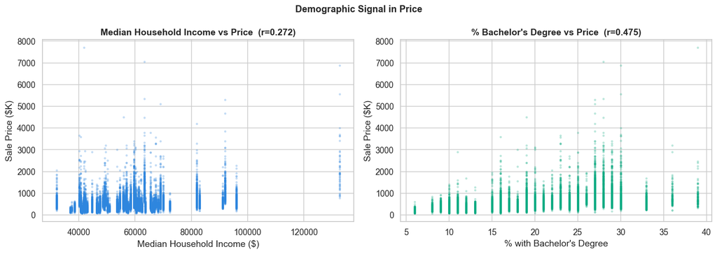

```python
# ── income vs median home value scatter ──────────────────────────────────
fig, axes = plt.subplots(1, 2, figsize=(14, 5))

axes[0].scatter(train_demo["medn_hshld_incm_amt"],
                train_demo["price"] / 1e3,
                alpha=0.2, s=5, color=PRICE_COLOR, rasterized=True)
r = train_demo[["medn_hshld_incm_amt","price"]].corr().iloc[0,1]
axes[0].set_title(f"Median Household Income vs Price  (r={r:.3f})", fontweight="bold")
axes[0].set_xlabel("Median Household Income ($)")
axes[0].set_ylabel("Sale Price ($K)")

axes[1].scatter(train_demo["per_bchlr"],
                train_demo["price"] / 1e3,
                alpha=0.2, s=5, color=GREEN, rasterized=True)
r2 = train_demo[["per_bchlr","price"]].corr().iloc[0,1]
axes[1].set_title(f"% Bachelor's Degree vs Price  (r={r2:.3f})", fontweight="bold")
axes[1].set_xlabel("% with Bachelor's Degree")
axes[1].set_ylabel("Sale Price ($K)")

plt.suptitle("Demographic Signal in Price", fontsize=13, fontweight="bold")
plt.tight_layout(); plt.show()
```

## 12 · Multicollinearity Check

```python
# ── VIF for top numeric features ─────────────────────────────────────────
from numpy.linalg import matrix_rank

vif_cols = ["sqft_living","sqft_above","sqft_living15",
            "bathrooms","bedrooms","grade","floors",
            "lat","long","house_age"]

X_vif = train[vif_cols].dropna()
corr_matrix = X_vif.corr().abs()

# highlight highly correlated pairs
high_corr_pairs = []
for i in range(len(corr_matrix.columns)):
    for j in range(i+1, len(corr_matrix.columns)):
        c = corr_matrix.iloc[i, j]
        if c > 0.7:
            high_corr_pairs.append({
                "Feature A": corr_matrix.columns[i],
                "Feature B": corr_matrix.columns[j],
                "Correlation": round(c, 3)
            })

hc = pd.DataFrame(high_corr_pairs).sort_values("Correlation", ascending=False)
if hc.empty:
    print("No feature pairs with |r| > 0.7")
else:
    print("Highly correlated pairs (|r| > 0.7):")
    print(hc.to_string(index=False))
```

```
Highly correlated pairs (|r| > 0.7):
    Feature A     Feature B  Correlation
  sqft_living    sqft_above        0.877
  sqft_living         grade        0.763
  sqft_living sqft_living15        0.756
   sqft_above         grade        0.756
  sqft_living     bathrooms        0.755
   sqft_above sqft_living15        0.732
sqft_living15         grade        0.713
```

## 13 · Train vs Future Set — Distribution Check

> Confirms that the unseen prediction set is drawn from the same distribution, so model generalisation is expected to hold.

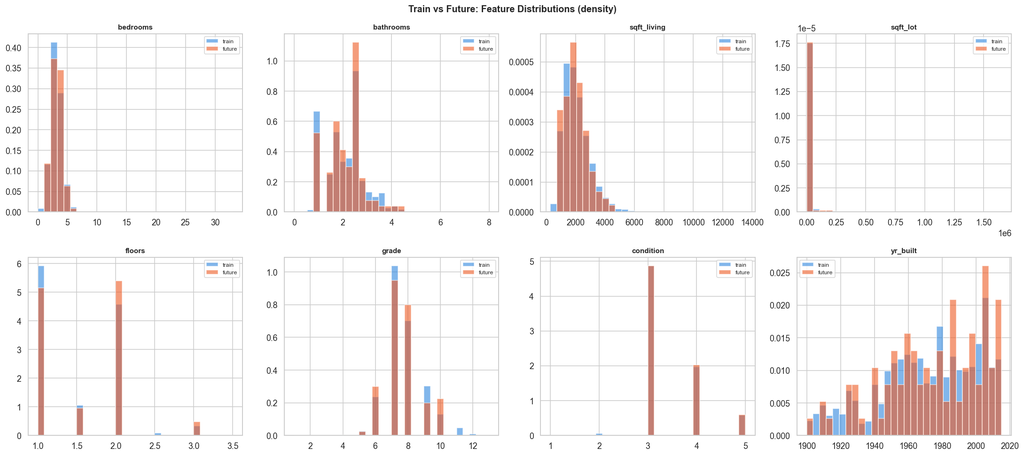

```python
compare_cols = ["bedrooms","bathrooms","sqft_living","sqft_lot",
                "floors","grade","condition","yr_built"]

fig, axes = plt.subplots(2, 4, figsize=(20, 9))
axes = axes.flatten()

for ax, col in zip(axes, compare_cols):
    bins = np.histogram_bin_edges(
        pd.concat([train[col], future[col]]).dropna(), bins=30)
    ax.hist(train[col],  bins=bins, alpha=0.6, label="train",  color=PRICE_COLOR,  edgecolor="white", density=True)
    ax.hist(future[col], bins=bins, alpha=0.6, label="future", color=ACCENT_COLOR, edgecolor="white", density=True)
    ax.set_title(col, fontweight="bold", fontsize=10)
    ax.legend(fontsize=8)

plt.suptitle("Train vs Future: Feature Distributions (density)", fontsize=13, fontweight="bold")
plt.tight_layout(); plt.show()
```

```python
# ── KS test for distributional similarity ─────────────────────────────
from scipy.stats import ks_2samp

print(f"{'Feature':<20} {'KS stat':>10} {'p-value':>12} {'Same dist?':>12}")
print("-" * 58)
for col in compare_cols:
    stat, p = ks_2samp(train[col].dropna(), future[col].dropna())
    same = "✓ yes" if p > 0.05 else "✗ no"
    print(f"{col:<20} {stat:>10.4f} {p:>12.4f} {same:>12}")
```

```
Feature                 KS stat      p-value   Same dist?
----------------------------------------------------------
bedrooms                 0.0521       0.9362        ✓ yes
bathrooms                0.0426       0.9899        ✓ yes
sqft_living              0.0554       0.9013        ✓ yes
sqft_lot                 0.0732       0.6298        ✓ yes
floors                   0.0725       0.6421        ✓ yes
grade                    0.0267       1.0000        ✓ yes
condition                0.0093       1.0000        ✓ yes
yr_built                 0.0667       0.7389        ✓ yes
```

## 14 · Engineered Feature Previews

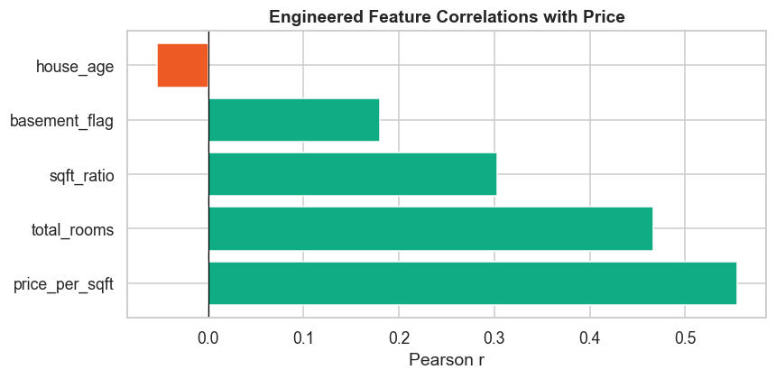

```
price_per_sqft    0.554703
total_rooms       0.466319
sqft_ratio        0.302547
basement_flag     0.180230
house_age        -0.054012
```

```python
train["price_per_sqft"]   = train["price"] / train["sqft_living"]
train["total_rooms"]      = train["bedrooms"] + train["bathrooms"]
train["basement_flag"]    = (train["sqft_basement"] > 0).astype(int)
train["sqft_ratio"]       = train["sqft_living"] / (train["sqft_living15"] + 1)

new_feats = ["price_per_sqft","total_rooms","basement_flag","sqft_ratio","house_age"]
new_corrs = train[new_feats + ["price"]].corr()["price"].drop("price").sort_values(key=abs, ascending=False)

fig, ax = plt.subplots(figsize=(8, 4))
colors = [GREEN if v > 0 else ACCENT_COLOR for v in new_corrs.values]
ax.barh(new_corrs.index, new_corrs.values, color=colors, edgecolor="white")
ax.axvline(0, color="black", linewidth=0.8)
ax.set_title("Engineered Feature Correlations with Price", fontweight="bold")
ax.set_xlabel("Pearson r")
plt.tight_layout(); plt.show()

print(new_corrs.to_string())
```

## 15 · EDA Summary & Modelling Recommendations

### Key Findings

[output not shown]

### Recommended Pre-Processing Checklist

- Log-transform target: `y = np.log1p(price)`
- Log-transform skewed features: `sqft_lot`, `sqft_lot15`
- Winsorise `bedrooms` at 10 (remove 33-bedroom anomaly)
- Create: `house_age`, `was_renovated`, `price_per_sqft`, `total_rooms`, `basement_flag`
- Merge `zipcode_demographics.csv` on `zipcode`
- Encode `zipcode` as ordinal or target-encode
- Fill `yr_renovated == 0` with `yr_built` (no renovation = built year as reference)